# Data Mining using R

Class Exercise 2 by Silvan H., Vishal A. and Kerim L.

03.05.2024

# How did media coverage of travel restrictions evolve during the COVID-19 pandemic?

## Topic of Interest

Particularly at the beginning of the COVID-19 pandemic, when no vaccines were available, physical interventions such as face masks, social distancing, lockdowns and travel restrictions were the main measures used to mitigate the effects of the COVID-19 pandemic. As such measures are effective when there is a high level of compliance within society, information about the rules and guidelines in place is required.

We are now interested in how media coverage regarding one of these physical interventions - travel restrictions - has evolved in a quantitative way over time.

## Data, Operationalisation and Methods

To investigate our subject of interest, we made use of the Guardian API. The Guardian API is a web service that allows access to over 2 million pieces of content (articles, video or audio) dating back to 1999.

### Data

```r
# Define base URL and parameters
base_url <- "https://content.guardianapis.com/search"
topic <- "covid-19 AND travel restrictions"

# Set API-key
api_key <- Sys.getenv("Guardian_API_KEY") # Key must be stored in .Renviron file to prevent publication of key

if (api_key == "") {
  stop("API key is not set. Please ensure your .Renviron file is configured correctly.") #Checks for API key and gives error message if not
}

pages <- list()

# GET request
 for (i in 1:50) {
    api_response1 <- GET(url = base_url,
                         query = list(q = topic,
                                      `api-key` = api_key,
                                      page = i,
                                      `page-size` = 50))

    if (status_code(api_response1) == 200) {
      content_data <- content(api_response1, "parsed")
      if (!is.null(content_data$response$results)) {
        pages <- append(pages, content_data$response$results)
      }
    } else {
      print(paste("Failed with status:", status_code(api_response1)))
      break #Breaks the loop if status code is not 200
    }
 }

# Converting matrix-list/nested structure into a dataframe
pages_flat <- bind_rows(pages)

# Creating a data frame by extracting information of interest
dat <- pages_flat %>%
  select(id_endpoint = id,
         section_name = sectionName,
         publish_date = webPublicationDate,
         title = webTitle)

# Save the data locally as a csv file
write_csv(dat, "../data_original/guardian_covid_travel.csv")
```

### Operationalisation

To investigate how media coverage of travel restrictions evolved over time, we created a variable “month_published” to cluster articles by month and year of publication.

```r
# load the data
dat <- read_csv("../data_original/guardian_covid_travel.csv")
# delete the variable id_endpoint
dat$id_endpoint <- NULL

#create a new variable month published based on publish_date
dat$month_published <- as.Date(dat$publish_date, format = "%Y-%m-%d") %>% format("%Y-%m")

# save the processed data
write_csv(dat, "../data_processed/guardian_covid_travel.csv")
```

### Methods

We then visualized the data by creating a bar chart that shows the number of articles covering “covid-19” and “travel restrictions” per month.

## Results

Not surprising, the number of articles covering “covid-19” and “travel restrictions” increased thought the years 2020 and 2021 with a peak at the end of 2021 when physical interventions were still in place due to the lack of vaccines. To our surprise, there is a second peak in the number of articles covering “covid-19” and “travel restrictions” that started at the beginning of 2024 - long after the pandemic was declared over - and could be still ongoing.

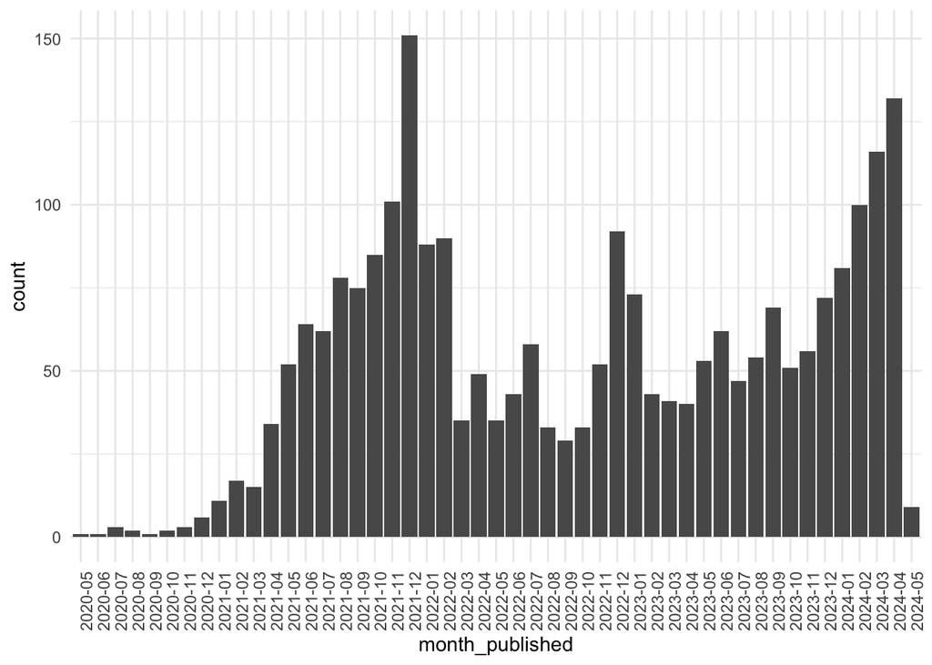

```r
dat %>%
  ggplot(aes(x = month_published)) +
  geom_bar() +
  theme_minimal() +
  theme(axis.text.x = element_text(angle = 90, hjust = 1))
```

## Discussion

We do not know what caused the second peak in the number of articles covering “covid-19” and “travel restrictions” in 2024. This could be an interesting topic of interest in a follow up project that focussed more on the qualitiative content of the articles instead of the quantitative aspect.